# tidyplot: An R package with diversy themes and colors for biological data visualization

##### 2.1.3. To browser combination of several beautiful colors in `tidyplot` package:

In `tidyplot` package, we designed some combinations for specific application situation, such as, embryonic stem cell development. You can directly using these combinations to visualize your data.

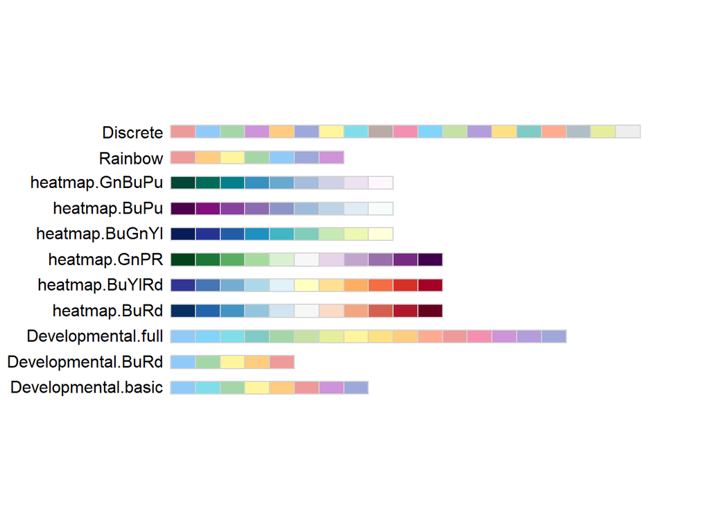

```r
display.color.all(type = "material.set")
```

To get the color code for above combinations:

```r
dev_basic <- material.color.set(name = "Developmental.basic")
dev_basic
```

```
## [1] "#90CAF9" "#80DEEA" "#A5D6A7" "#FFF59D" "#FFCC80" "#EF9A9A" "#CE93D8"
## [8] "#9FA8DA"
```

If you have other creative combinations, please let me known, and I’ll be happy to add into out package.

#### 2.2 Get the colors from `tidyplot` package

##### 2.2.1 get colors with different brightness

If you are considering using one type of color to visualize the intensity change, e.g. heatmaps with values between 0 to 1. you can get 19 types of colors from `tidyplot` with up to 10 different brightness. For example, you can get 6 gradient red colors:

```r
Reds <- material.colors(name = "Red", brightness = 1:6)
Reds
```

```
##        A1        A2        A3        A4        A5        A6
## "#FFEBEE" "#FFCDD2" "#EF9A9A" "#E57373" "#EF5350" "#F44336"
```

To visualize the above colors:

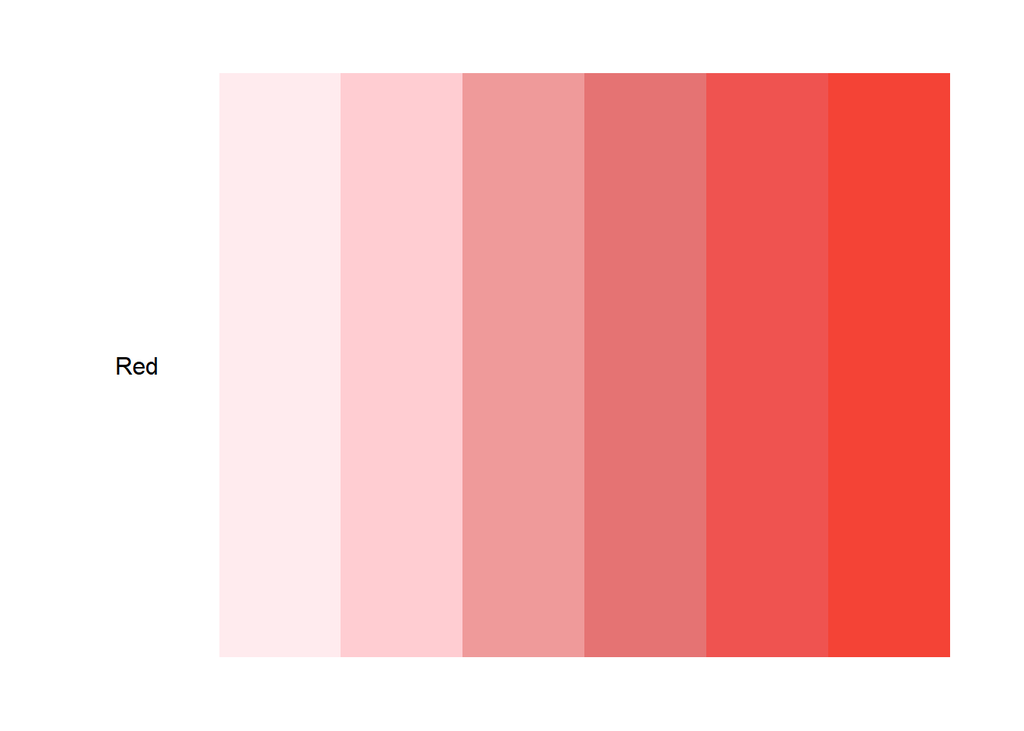

```r
display.color(colors = Reds, color_name = "Red")
```

##### 2.2.2 get colors from `RColorBrewer` package

Here, we can get colors from `RColorBrewer` package by using the function `brewer.colors()`:

```r
RdBu <- brewer.colors(name = 'RdBu',n = 11)
RdBu
```

```
##  [1] "#67001F" "#B2182B" "#D6604D" "#F4A582" "#FDDBC7" "#F7F7F7" "#D1E5F0"
##  [8] "#92C5DE" "#4393C3" "#2166AC" "#053061"
```

To visualize the above colors:

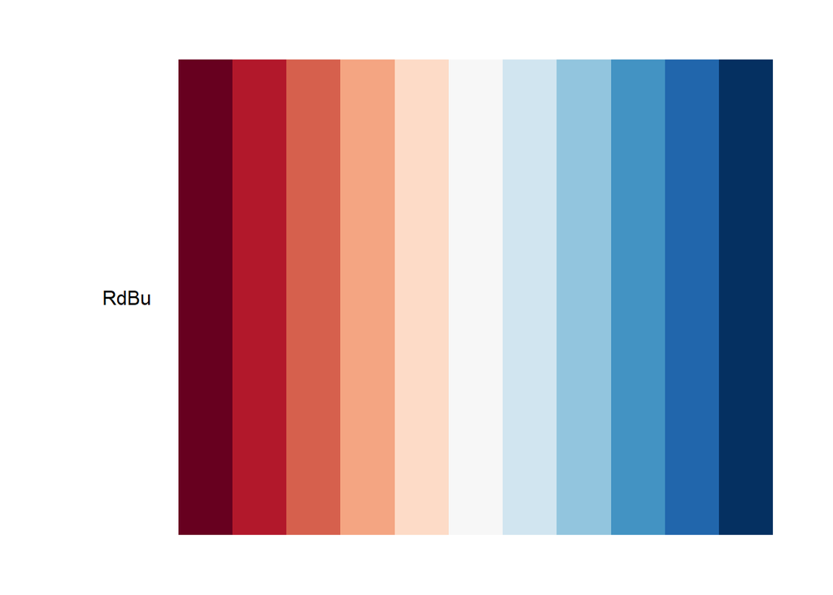

```r
display.color(colors = RdBu, color_name = "RdBu")
```

##### 2.2.3 get specific numbers of colors

The above gradient colors may not enough to visualize heatmaps. We can use `adjust.color.number()` function to expand or shrink our color to an specific number:

```r
RdBu100 <- adjust.color.number(color = RdBu,n = 100)
RdBu100
```

```
##   [1] "#67001F" "#6E0220" "#760421" "#7D0722" "#850923" "#8C0C25" "#940E26"
##   [8] "#9C1027" "#A31328" "#AB1529" "#B2182B" "#B6202E" "#B92732" "#BD2E35"
##  [15] "#C03539" "#C43D3C" "#C8443F" "#CB4B43" "#CF5246" "#D35A4A" "#D6614E"
##  [22] "#D96853" "#DC6F58" "#DF765E" "#E27D63" "#E58468" "#E88B6E" "#EB9273"
##  [29] "#EE9978" "#F1A07E" "#F4A684" "#F5AC8B" "#F6B192" "#F7B799" "#F7BC9F"
##  [36] "#F8C1A6" "#F9C7AD" "#FACCB4" "#FBD2BB" "#FCD7C2" "#FCDCC8" "#FCDECD"
##  [43] "#FBE1D2" "#FAE4D7" "#FAE7DC" "#F9EAE1" "#F9EDE6" "#F8EFEA" "#F7F2EF"
##  [50] "#F7F5F4" "#F5F6F6" "#F1F4F5" "#EDF2F5" "#E9F0F4" "#E5EEF3" "#E1EDF3"
##  [57] "#DEEBF2" "#DAE9F1" "#D6E7F0" "#D2E5F0" "#CDE3EE" "#C6DFED" "#C0DCEB"
##  [64] "#BAD9E9" "#B3D6E7" "#ADD2E5" "#A7CFE4" "#A0CCE2" "#9AC9E0" "#93C5DE"
##  [71] "#8CC1DC" "#84BCD9" "#7CB7D6" "#74B2D3" "#6CADD1" "#64A8CE" "#5CA3CB"
##  [78] "#549EC9" "#4C99C6" "#4494C3" "#408FC1" "#3C8ABE" "#3986BC" "#3581BA"
##  [85] "#327DB7" "#2F78B5" "#2B74B3" "#286FB0" "#246AAE" "#2166AC" "#1E61A5"
##  [92] "#1B5B9D" "#185696" "#15508E" "#134B86" "#10457F" "#0D4077" "#0A3A70"
##  [99] "#073568" "#053061"
```

Then, visualize them:

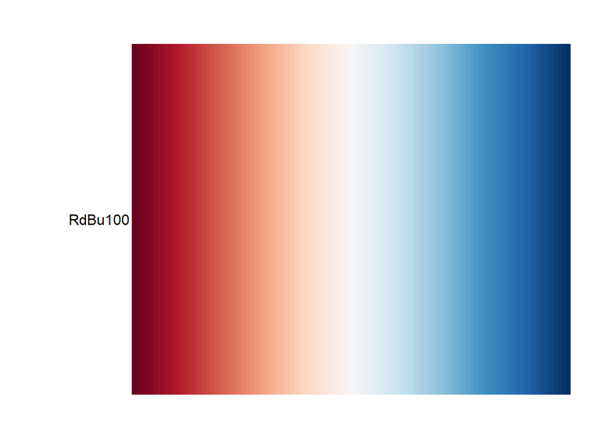

```r
display.color(colors = RdBu100, color_name = "RdBu100")
```

#### 2.3 get all colors you wanted from `tidyplot`

All the colors in `tidyplot` were deposited in `tidyplot::materialColorBrewer`, you can download the color matrix for your own design.

### 3. Instructions for themes in `ggplot2`

Here we designed a few themes that are frequently used in data visualization.

#### 3.1 Basic theme `theme_basic()`

The basic theme removes background and useless panel grids. It’s very useful to remove these element when you editing your figures in Adobe Illustrator (AI).

Here is the default theme:

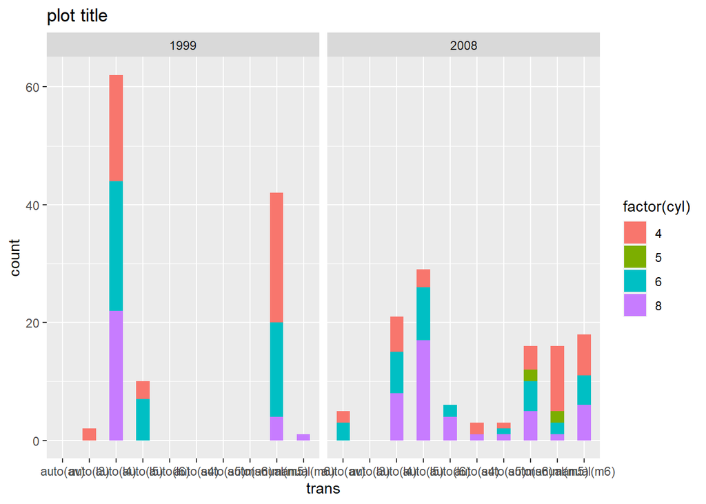

```r
library(ggplot2)
library(tidyplot)
p1 <- ggplot(data = mpg, aes(x = trans, fill = factor(cyl)))+
  geom_bar(width = 0.5, color = NA)+
  labs(title = "plot title")+
  facet_wrap(.~year)
p1
```

There are few issues in default theme:

1). The title is not centered-aligned;

2). Gray background;

3). Gray strip background on each panel;

4). Gray background under legend;

5). No axis lines at x and y-axis;

Here is the updated version of theme, we modified the above issues:

1). The CNS journal requires font size between 5 - 7pt, so we set all the font size at 6pt by default;

2). The CNS journal requires line width should be larger the 0.3pt, here we set 1px by default;

3). The text color at x- and y-axis is not black, we set all the font color in black by default;

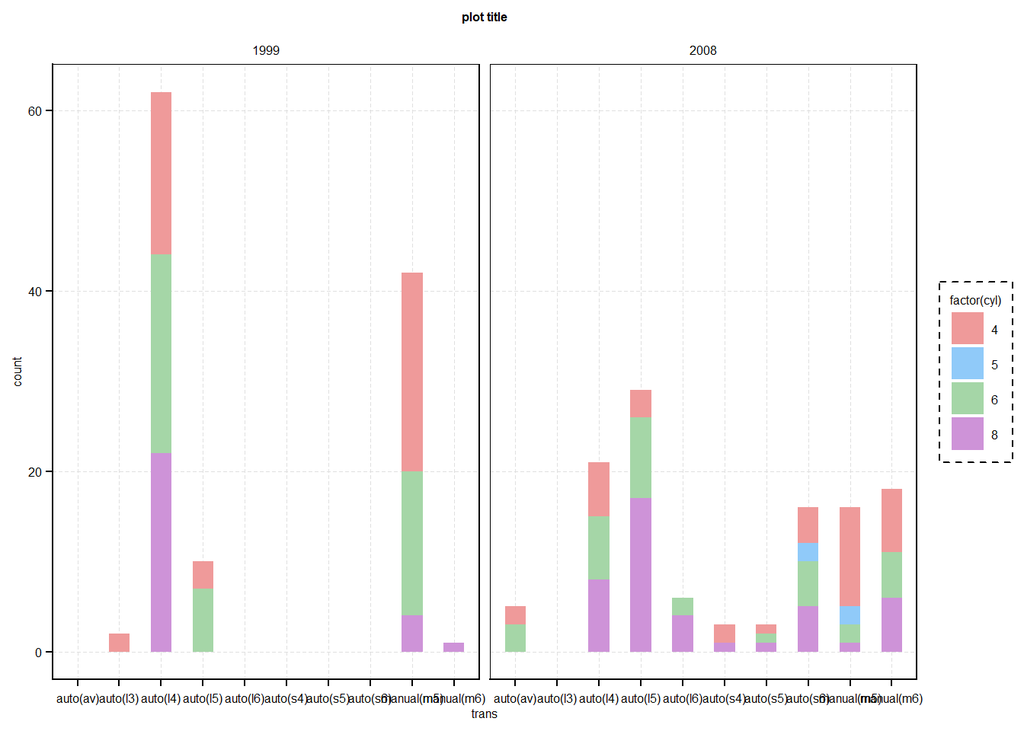

```r
p1+theme_basic()+ scale_fill_manual(values = material.color.set(name = 'Discrete', brightness = 3))
```

#### 3.2 Slope theme `theme_slpoe()`

From above figure, you will find the space at x-axis is not enough to show all the items, so you can slope these items by 45 degree using `theme_slope()`.

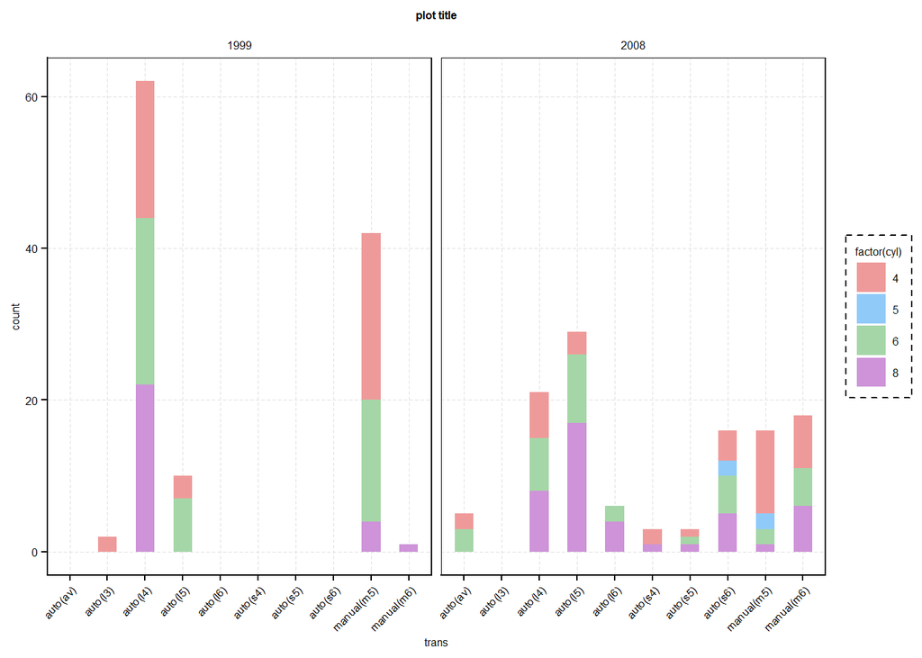

```r
p1+theme_slope()+scale_fill_manual(values = material.color.set(name = 'Discrete', brightness = 3))
```

If you prefer the classical theme, you can use `theme_clean()`, we removed the border and only keep the axis lines at x and y-axis:

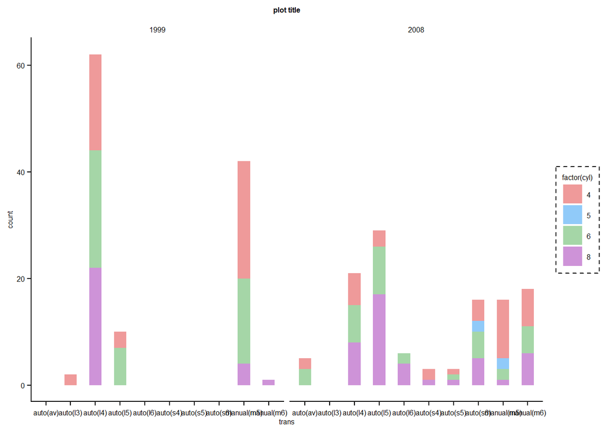

```r
p1+theme_clean()+scale_fill_manual(values = material.color.set(name = 'Discrete', brightness = 3))
```

All above themes were summarized with my experience when perform data visualization with `ggplot2`. By removing some useless elements from your figures will speed up editing your figures with Adobe Illustrator. You can also setting the theme.

#### 3.4 Other themes in `ggplot2`

There are lots of themes in `ggplot2`, such as `theme_bw()`, `theme_linedraw()`, `theme_light()`, `theme_dark()`, `theme_minimal()`, `theme_classic()`, and `theme_void()`. Please refer to [Themes](https://ggplot2-book.org/polishing.html).

### 4. Commonly used figures in data visualization

#### 4.1 Dot plot

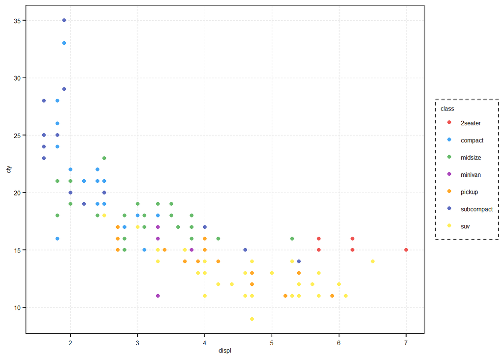

```r
library(ggplot2)
library(tidyplot)

p2 <- ggplot(data = mpg, mapping = aes(x = displ, y = cty, color = class))+
  geom_point(shape=16)+
  scale_color_manual(values = material.color.set(name = 'Discrete', brightness = 5))+
  theme_basic()

p2
```

#### 4.2 Bar plot

##### 4.2.1 Bar plot with stack position

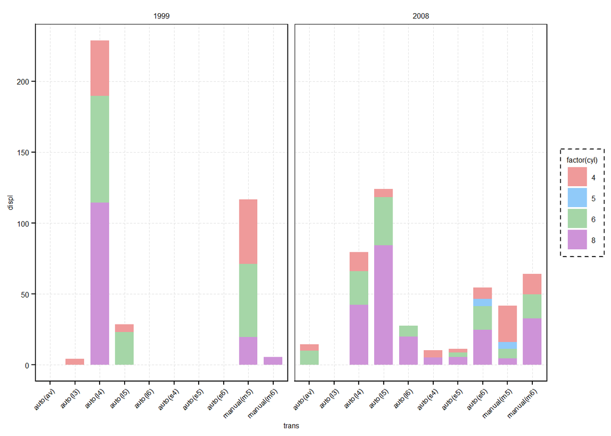

```r
p3 <- ggplot(data = mpg, aes(x = trans, y = displ, fill = factor(cyl)))+
  geom_bar(stat = 'identity', position = 'stack',color=NA, width=0.75)+
  scale_fill_manual(values = material.color.set(name = 'Discrete', brightness = 3))+
  theme_slope()+
  facet_grid(.~year)

p3
```

##### 4.2.2 Bar plot with dodge position

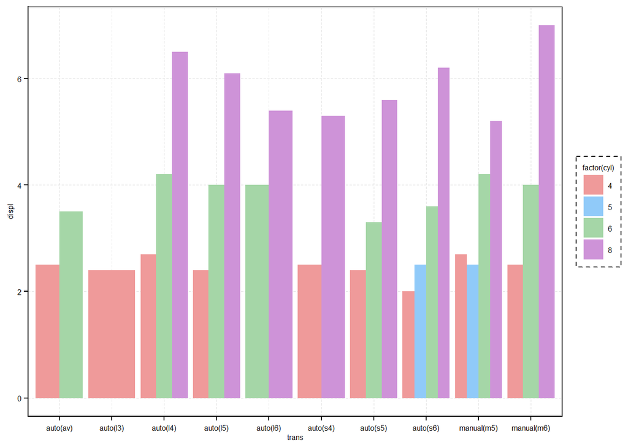

```r
p4 <- ggplot(data = mpg, aes(x = trans, y = displ, fill = factor(cyl)))+
  geom_bar(stat = 'identity', position = 'dodge',color=NA)+
  scale_fill_manual(values = material.color.set(name = 'Discrete', brightness = 3))+
  theme_basic()

p4
```

##### 4.2.3 Bar plot with fill position

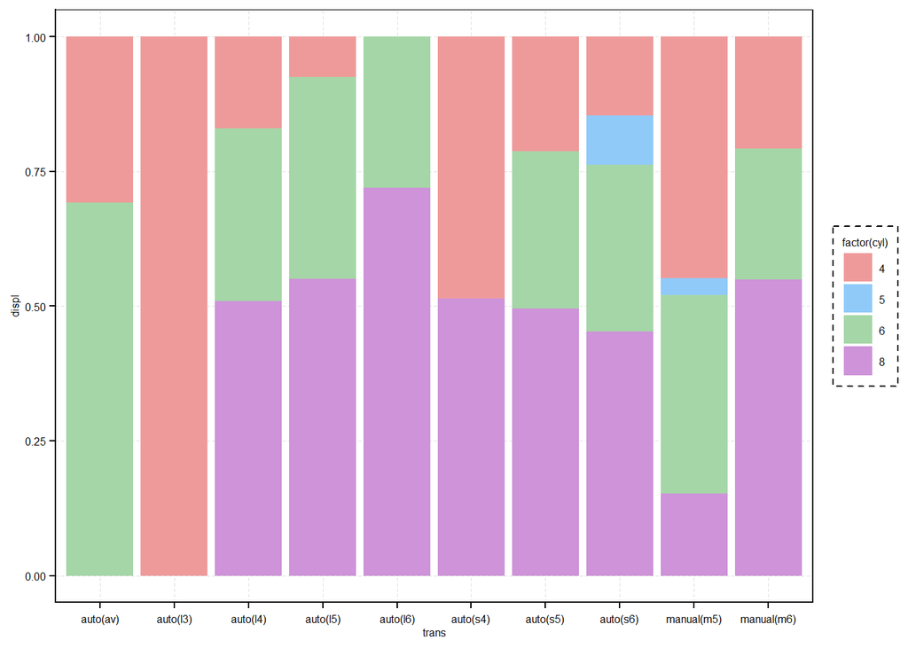

```r
p5 <- ggplot(data = mpg, aes(x = trans, y = displ, fill = factor(cyl)))+
  geom_bar(stat = 'identity', position = 'fill',color=NA)+
  scale_fill_manual(values = material.color.set(name = 'Discrete', brightness = 3))+
  theme_basic()

p5
```

##### 4.2.4 Pie plot with fill position

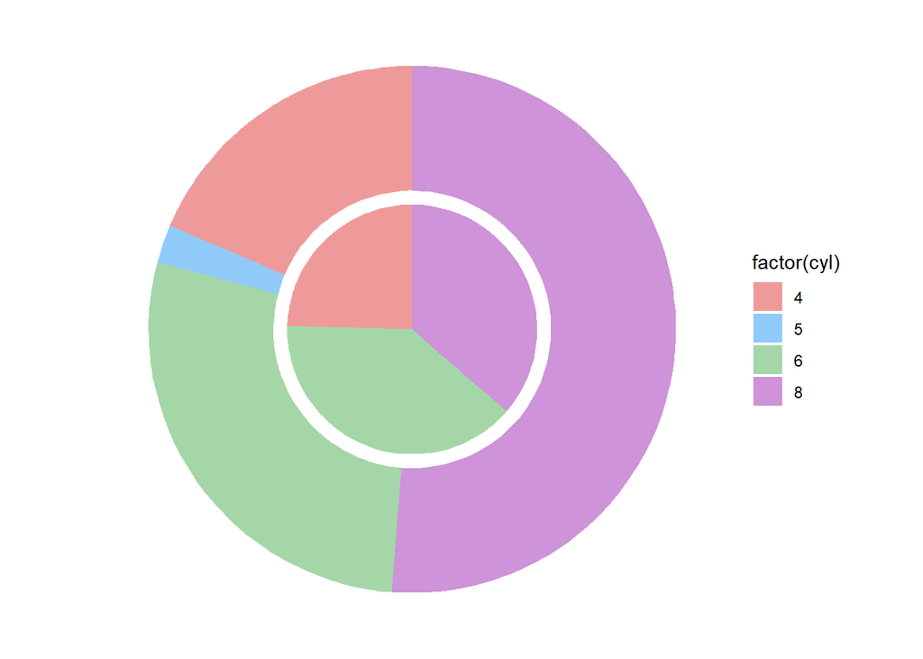

```r
p6 <- ggplot(data = mpg, aes(x = year, y = displ, fill = factor(cyl)))+
  geom_bar(stat = 'identity', position = 'fill',color=NA)+
  scale_fill_manual(values = material.color.set(name = 'Discrete', brightness = 3))+
  coord_polar(theta = "y")+
  theme_void()

p6
```

#### 4.3 Violin plot

##### 4.3.1 Violin plot

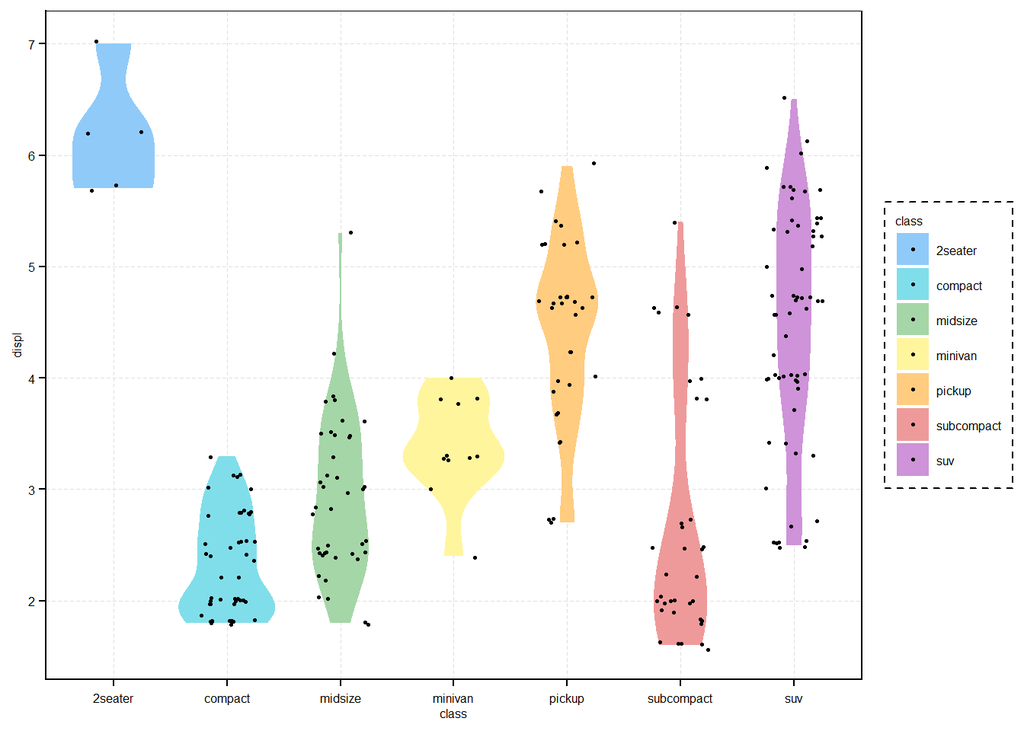

```r
p7 <- ggplot(data = mpg, aes(x = class, y = displ, color = class, fill=class))+
  geom_violin(color=NA)+
  geom_jitter(width=0.25, size=0.5, shape=16, color='#000000', alpha = 1)+
  scale_fill_manual(values = material.color.set(name = 'Developmental.basic', brightness = 3))+
  theme_basic()

p7
```

##### 4.3.2 Boxplot

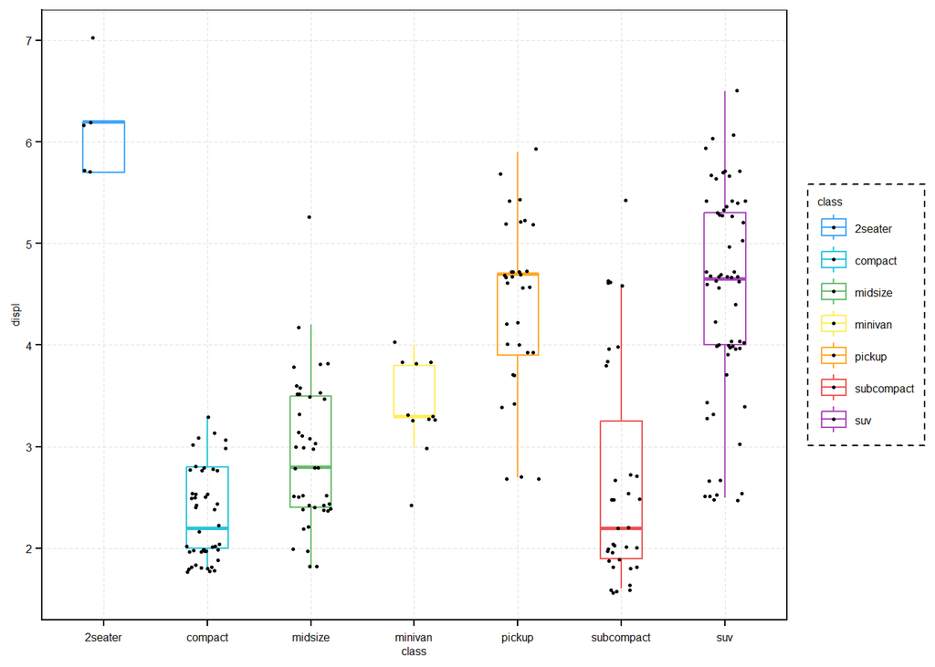

```r
p8 <- ggplot(data = mpg, aes(x = class, y = displ, color = class, fill=class))+
  geom_boxplot(width=0.4,fill = NA, size=0.5,outlier.colour=NA, alpha = 0.8)+
  geom_jitter(width=0.2, size = 0.5, shape=16, color='#000000', alpha = 1)+
  scale_color_manual(values = material.color.set(name = 'Developmental.basic', brightness = 5))+
  scale_fill_manual(values = material.color.set(name = 'Developmental.basic', brightness = 3))+
  theme_basic()

p8
```

#### 4.4 Density plot

##### 4.4.1 The density distribution from the same base level

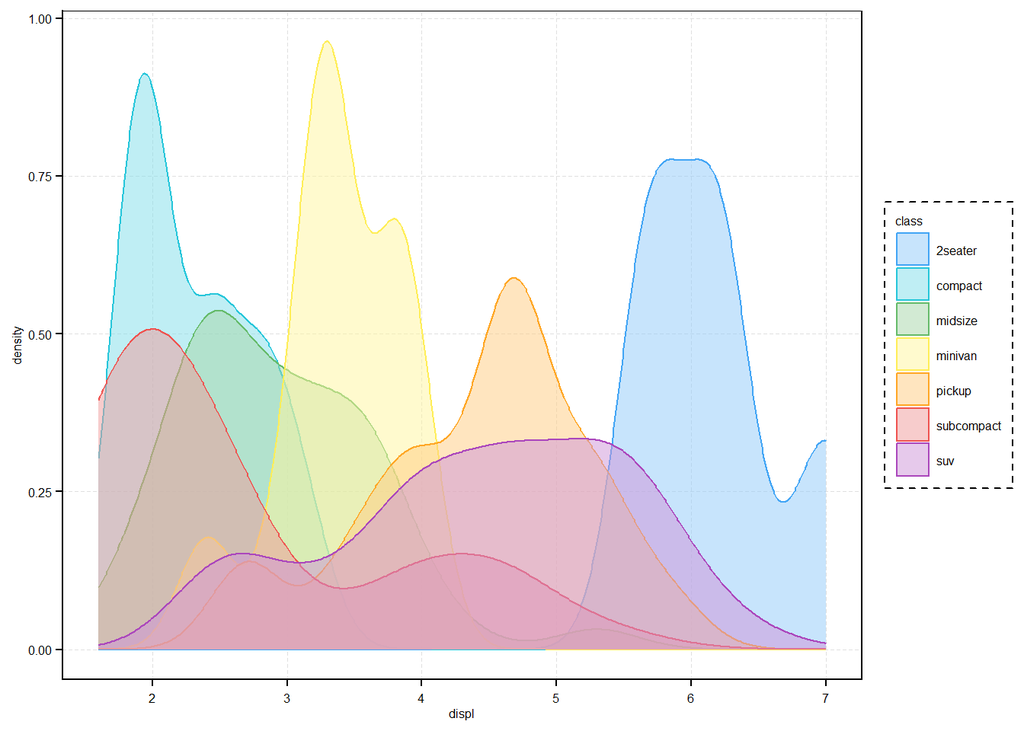

```r
p9 <- ggplot(data = mpg, aes(x = displ, color = class, fill=class))+
  geom_density(alpha=0.5)+
  scale_color_manual(values = material.color.set(name = 'Developmental.basic', brightness = 5))+
  scale_fill_manual(values = material.color.set(name = 'Developmental.basic', brightness = 3))+
  theme_basic()

p9
```

##### 4.4.2 Split the density distribution from y-axis

```r
library(ggridges)
```

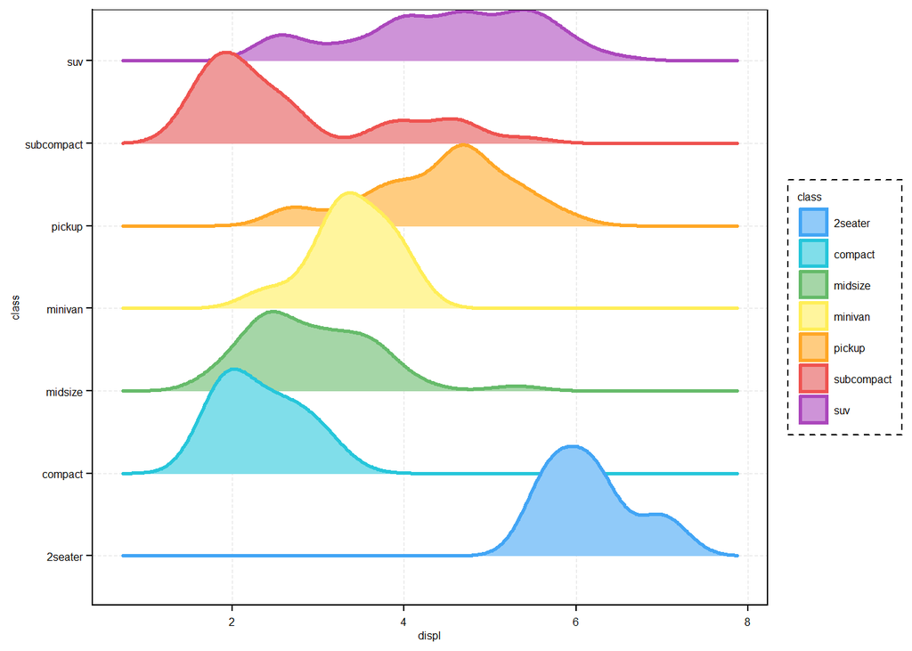

```r
p10 <- ggplot(data = mpg, aes(x = displ, y = class, color = class, fill=class))+
  geom_density_ridges_gradient(size = 1, scale = 1.4, panel_scaling = F, alpha=.8,na.rm=T)+
  scale_color_manual(values = material.color.set(name = 'Developmental.basic', brightness = 5))+
  scale_fill_manual(values = material.color.set(name = 'Developmental.basic', brightness = 3))+
  theme_basic()
p10
```

##### 4.4.3 Cumulative distribution plot

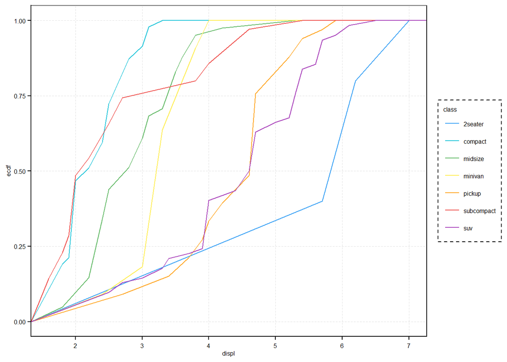

```r
p11 <- ggplot(data = mpg, aes(x = displ, color = class, fill=class))+
  stat_ecdf(geom="line")+
  scale_color_manual(values = material.color.set(name = 'Developmental.basic', brightness = 5))+
  theme_basic()
p11
```

#### 4.5. Radviz plot

##### 4.5.1 Tern plot

Tern plot describe the relative enrichment of three features, suitable for stage-specific enrichment genes among three stages.

```r
library(ggtern)
```

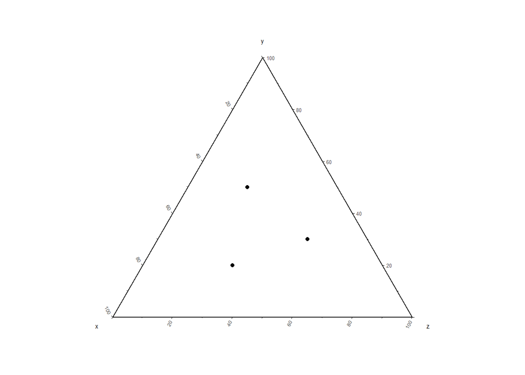

```r
df <- data.frame(
  x = c(0.2, 0.5, 0.3),
  y = c(0.3, 0.2, 0.5),
  z = c(0.5, 0.3, 0.2)
)
p12 <- ggtern(data = df, mapping = aes(x = x,y = y,z = z))+
  geom_point()+
  theme_basic()

p12
```

##### 4.5.2 Radviz plot

Here we use can visualize the relative enrichment of different types using methods in `SubLocR`, this method can used to visualize relative enrichment with more than 3 stages or any number of stages.

```r
devtools::install_github("hmutpw/SubLocR")
library(SubLocR)
```

```r
data("ESC_RSL_data")

radviz_obj <- getRadObj(input_frm = ESC_RSL_data$D0[1:20,], anchors = c('CE','ME','SNE','CBNE','PE'))
```

```
## Selected optimization function: in.da
## Starting performance: -4.318675
## 0 Current performance: -4.318675
## 1 Current performance: -4.318675
## 2 Current performance: -4.318675
## 3 Current performance: -4.318675
## 4 Current performance: -4.318675
## 5 Current performance: -4.318675
## 6 Current performance: -4.318675
## Execution stopped after 6 iterations: no better solution found in the last 5 iterations
```

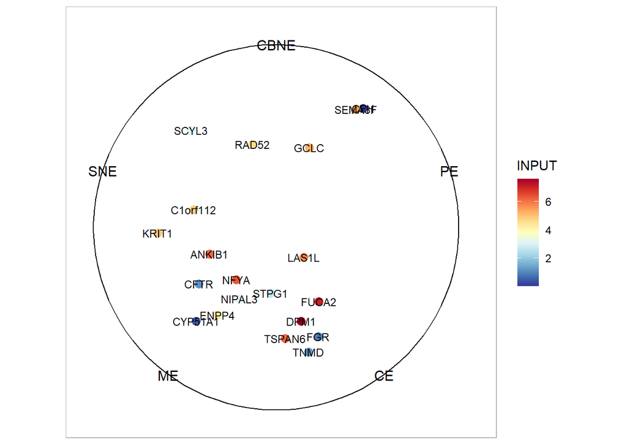

```r
p13 <- do_RadvizEnrichPlot(rv = radviz_obj, color_by = 'INPUT',point_size = 3)+
  geom_text(mapping = aes(label=gene_name),size=3)
p13
```